# **Dogs-vs-Cats Image Classification**

## *by Micha Birklbauer*

### Dataset: [Dogs-vs-Cats](https://www.kaggle.com/c/dogs-vs-cats)

## **Summary:**

```python
set_1 = ["model_cnn_rgb", "model_cnn_rgb_batchnorm", "model_cnn_rgb_reg", "model_cnn_rgb_resnet", "model_cnn_rgb_vgg"]
set_1_a = [0.703, 0.7475, 0.7795, 0.586, 0.742]
set_2 = ["model_cnn_rgb_aug", "model_cnn_rgb_batchnorm_aug", "model_cnn_rgb_reg_aug", "model_cnn_rgb_resnet_aug", "model_cnn_rgb_vgg_aug", "model_cnn_rgb_vgg2_aug"]
set_2_a = [0.791, 0.7955, 0.825, 0.653, 0.728, 0.8065]
set_3 = ["model_cnn_rgb_mean", "model_cnn_rgb_batchnorm_mean", "model_cnn_rgb_reg_mean", "model_cnn_rgb_resnet_mean", "model_cnn_rgb_vgg_mean", "model_cnn_rgb_vgg2_mean"]
set_3_a = [0.7755, 0.772, 0.789, 0.5, 0.743, 0.793]
set_4 = ["model_cnn_grey", "model_cnn_grey_batchnorm", "model_cnn_grey_reg"]
set_4_a = [0.7245, 0.7115, 0.763]
set_5 = ["model_cnn_rgbs", "model_cnn_rgbs_batchnorm", "model_cnn_rgbs_reg", "model_cnn_rgbs_res", "model_cnn_rgbs_vgg", "model_cnn_rgbs_vgg2", "model_cnn_rgbs_vgg2_aug"]
set_5_a = [0.763, 0.813, 0.8285, 0.772, 0.8435, 0.879, 0.903]

import pandas as pd

models = set_1 + set_2 + set_3 + set_4 + set_5
accuracies = set_1_a + set_2_a + set_3_a + set_4_a + set_5_a
results = pd.DataFrame({"models":models, "accuracy":accuracies}).sort_values(by="accuracy", ascending=False)

results
```

|  | models | accuracy |
| --- | --- | --- |
| 26 | model_cnn_rgbs_vgg2_aug | 0.9030 |
| 25 | model_cnn_rgbs_vgg2 | 0.8790 |
| 24 | model_cnn_rgbs_vgg | 0.8435 |
| 22 | model_cnn_rgbs_reg | 0.8285 |
| 7 | model_cnn_rgb_reg_aug | 0.8250 |
| 21 | model_cnn_rgbs_batchnorm | 0.8130 |
| 10 | model_cnn_rgb_vgg2_aug | 0.8065 |
| 6 | model_cnn_rgb_batchnorm_aug | 0.7955 |
| 16 | model_cnn_rgb_vgg2_mean | 0.7930 |
| 5 | model_cnn_rgb_aug | 0.7910 |
| 13 | model_cnn_rgb_reg_mean | 0.7890 |
| 2 | model_cnn_rgb_reg | 0.7795 |
| 11 | model_cnn_rgb_mean | 0.7755 |
| 12 | model_cnn_rgb_batchnorm_mean | 0.7720 |
| 23 | model_cnn_rgbs_res | 0.7720 |
| 19 | model_cnn_grey_reg | 0.7630 |
| 20 | model_cnn_rgbs | 0.7630 |
| 1 | model_cnn_rgb_batchnorm | 0.7475 |
| 15 | model_cnn_rgb_vgg_mean | 0.7430 |
| 4 | model_cnn_rgb_vgg | 0.7420 |
| 9 | model_cnn_rgb_vgg_aug | 0.7280 |
| 17 | model_cnn_grey | 0.7245 |
| 18 | model_cnn_grey_batchnorm | 0.7115 |
| 0 | model_cnn_rgb | 0.7030 |
| 8 | model_cnn_rgb_resnet_aug | 0.6530 |
| 3 | model_cnn_rgb_resnet | 0.5860 |
| 14 | model_cnn_rgb_resnet_mean | 0.5000 |

## **Applying the model to some of my own images:**

```python
from matplotlib import pyplot as plt
import imageio
import numpy as np
import cv2
from tensorflow.keras.models import load_model
# I may have missed some dependencies for this function here, did this at the end with everything loaded

def apply_to_image(file):
    img = imageio.imread(file, as_gray=False)
    plt.figure()
    plt.imshow(img)
    plt.show()

    model = load_model("Dogs-vs-Cats/trainResults/model_cnn_rgbs_vgg2_aug.h5")

    dim=model.input.shape.as_list()


    img = cv2.resize(img, dsize=(dim[1],dim[2]), interpolation=cv2.INTER_CUBIC)
    img = np.reshape(img,[1,dim[1],dim[2],3])
    classes = {0:"cat", 1:"dog"}
    prediction = model.predict(img)

    print("Predicted: ", classes[np.argmax(prediction)])
```

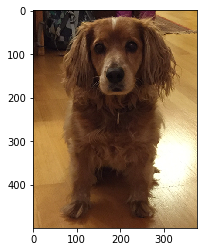

```
Predicted:  dog
```

```python
apply_to_image("Dogs-vs-Cats/custom/1.jpg")
```

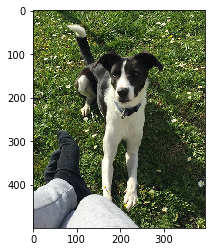

```
Predicted:  dog
```

```python
apply_to_image("Dogs-vs-Cats/custom/2.jpg")
```

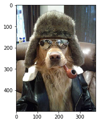

```
Predicted:  dog
```

```python
apply_to_image("Dogs-vs-Cats/custom/3.jpg")
```

**Most importantly, it should be able to predict animals in memes:**

[figure not shown]

```python
img = imageio.imread("Dogs-vs-Cats/custom/m1.jpg", as_gray=False)
plt.figure()
plt.imshow(img)
plt.show()
```

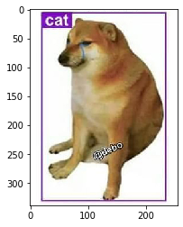

```
Predicted:  dog
```

```python
apply_to_image("Dogs-vs-Cats/custom/4.jpg")
```

[figure not shown]

```python
img = imageio.imread("Dogs-vs-Cats/custom/m2.jpg", as_gray=False)
plt.figure()
plt.imshow(img)
plt.show()
```

[figure not shown]

```
Predicted:  cat
```

```python
apply_to_image("Dogs-vs-Cats/custom/5.jpg")
```

#### **How to run this notebook:**

The directory structure to run this notebook has to be the following:

```python
# /Dogs-vs-Cats
#     /images
#         /cat
#            cat.*.jpg
#         /dog
#            dog.*.jpg
# Cat-vs-Dog_Classification_MichaBirklbauer.ipynb
```

#### **Creating the dataset:**

```python
import imageio
import numpy as np
from tqdm import tqdm
from matplotlib import pyplot as plt
from matplotlib import image
from collections import Counter
import os
import cv2
import shutil
import pickle
```

```python
imagePath="Dogs-vs-Cats/images/"
dataPath="Dogs-vs-Cats/"

classNames=os.listdir(imagePath)
classes={classNames[i]: i for i in range(len(classNames))}


output=dataPath+'/dataSet/'
testDir=dataPath+'./testDataSet/'
#manage directory
if not os.path.exists(output):
    os.makedirs(output)

if not os.path.exists(testDir):
    os.makedirs(testDir)
```

```python
#test image size
minx=1024
miny=1024
sx=[]
sy=[]
meansR=[]
meansG=[]
meansB=[]

#iterate images for required information
for className in tqdm(classNames):
    classFiles=os.listdir(imagePath+className)
    classFiles=[x for x in classFiles if x.endswith('.jpg')]
    for file in classFiles:
        try:
            img = imageio.imread(imagePath+className+"/"+file,as_gray=False)
            s=np.shape(img)
            minx=np.minimum(s[0],minx)
            miny=np.minimum(s[1],miny)
            sx.append(s[0])
            sy.append(s[1])
            meansR.append(np.mean(img[:,:,0]))
            meansG.append(np.mean(img[:,:,1]))
            meansB.append(np.mean(img[:,:,2]))

        except:
            print('Failed to process file:\n'+imagePath+className+"/"+file)

print('minx: {0} | miny: {1}'.format(minx,miny))
meanx=int(np.mean(sx))
meany=int(np.mean(sy))
print('meanx: {0} | meany: {1}'.format(meanx,meany))

meanR=np.mean(meansR)
meanG=np.mean(meansG)
meanB=np.mean(meansB)
means=[meanR,meanG,meanB]
with open("Dogs-vs-Cats/means.pickle", "wb") as output_file:
    pickle.dump(means, output_file)

print('meanR: {0} | meanG: {1} | meanB: {2}'.format(meanR,meanG,meanB))
```

```
minx: 32 | miny: 42
meanx: 360 | meany: 404
meanR: 124.52171153949787 | meanG: 116.0444763713438 | meanB: 106.32501154523678
```

```python
def meanSubstraction(img,means):
    normImg=np.copy(img).astype('float32')
    for i in range(len(normImg[1,1,:])):
        normImg[:,:,i]=normImg[:,:,i]-means[i]
    normImg=normImg/255.0
    return normImg
```

```python
#dataset parameter
data=[]
labels=[]
testSize=1000
size=np.minimum(minx,miny)
#size=250

#create datasets
for className in tqdm(classNames):
  print('\n'+className+'\n')
  classFiles=os.listdir(imagePath+className)
  classFiles=[x for x in classFiles if x.endswith('.jpg')]
  for i in range(testSize):
    file=classFiles[i]
    try:
        src=imagePath+className+"/"+file
        dst=testDir+"/"+className+'('+str(i)+').jpg'
        shutil.copy(src,dst)
    except:
        print('Could not copy file:\n'+file)
  classFiles=classFiles[testSize:]
  for file in classFiles:
    try:
        img = imageio.imread(imagePath+className+"/"+file,as_gray=False)
        label = classes[className]

        #scale image
        img = cv2.resize(img, dsize=(size,size), interpolation=cv2.INTER_CUBIC)
        img=np.reshape(img,(size,size,3))
        #img=meanSubstraction(img,means)
        data.append(img.astype('float32'))
        labels.append(label)
    except:
        print('Failed to process file:\n'+imagePath+className+"/"+file)
```

```
cat
```

```
dog
```

```python
#class balancing
from collections import Counter

limit=min(Counter(labels).values())
#create final dataset
labelsBalanced=[]
dataBalanced=[]
classes=np.unique(labels)
for c in classes:
    print('Class {0}'.format(c))
    idx = np.where(labels == c)
    idx = idx[0].tolist()
    np.random.shuffle(idx)
    for i in tqdm(range(0,limit)):
        labelsBalanced.append(c)
        dataBalanced.append(data[idx[i]])

del labels
del data

#one hot encoding for classlabels
from sklearn.preprocessing import LabelEncoder
from keras.utils import np_utils

lab = LabelEncoder()
encodedLabels = np_utils.to_categorical(lab.fit_transform(labelsBalanced))

#save dataset + labels
np.save(output+'data', dataBalanced)
np.save(output+'labels', encodedLabels)
```

```
Class 0
Class 1
```

#### **Comparison of Image vs. Mean-substracted Image:**

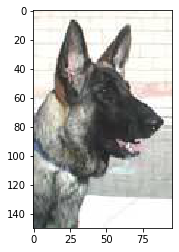

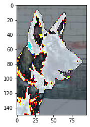

```python
img = imageio.imread(imagePath+className+"/"+file,as_gray=False)
plt.figure()
plt.imshow(img)
plt.show()
img=meanSubstraction(img,means)
plt.figure()
plt.imshow(img)
plt.show()
```

#### **Models:**

```python
import numpy as np
from sklearn.model_selection import train_test_split
import os

from tensorflow.keras import backend as K
from tensorflow.keras.optimizers import Adam
from tensorflow.keras.metrics import categorical_crossentropy
import matplotlib.pyplot as plt
from tensorflow.keras.callbacks import EarlyStopping,ModelCheckpoint

from tensorflow.keras import optimizers
from contextlib import redirect_stdout
from tensorflow.keras.preprocessing.image import ImageDataGenerator
from tensorflow.keras import optimizers

from tensorflow.keras.models import *
from tensorflow.keras.layers import *

from tensorflow.keras.regularizers import l2
from tensorflow.keras.models import Model
from tensorflow.keras.applications import ResNet50, VGG16

import time
import datetime
```

**CNN:**

```python
def getCNN(input_shape,classes):

    model = Sequential()
    model.add(Conv2D(32, (5,5), padding='same', input_shape=input_shape, activation='relu'))
    model.add(Conv2D(32, (5,5), padding='same', input_shape=input_shape, activation='relu'))
    model.add(MaxPooling2D(pool_size=(2,2)))

    model.add(Conv2D(64, (3,3), padding='same', activation='relu',))
    model.add(MaxPooling2D(pool_size=(2,2)))

    model.add(Conv2D(128, (3,3), padding='same', activation='relu'))
    model.add(MaxPooling2D(pool_size=(2,2)))
    model.add(Conv2D(128, (3,3), padding='same', activation='relu'))
    model.add(MaxPooling2D(pool_size=(2,2)))

    model.add(Flatten())
    model.add(Dense(512, activation='relu'))
    model.add(Dense(512, activation='relu'))
    model.add(Dense(classes))
    model.add(Activation('softmax'))

    return model
```

**CNN with batch-normalization and dropout:**

```python
def getCNN_batchnorm(input_shape,classes):

    model = Sequential()
    model.add(Conv2D(32, (5,5), padding='same', input_shape=input_shape, activation='relu'))
    model.add(Conv2D(32, (5,5), padding='same', input_shape=input_shape, activation='relu'))
    model.add(BatchNormalization())
    model.add(MaxPooling2D(pool_size=(2,2)))

    model.add(Conv2D(64, (3,3), padding='same', activation='relu',))
    model.add(MaxPooling2D(pool_size=(2,2)))

    model.add(Conv2D(128, (3,3), padding='same', activation='relu'))
    model.add(MaxPooling2D(pool_size=(2,2)))
    model.add(Conv2D(128, (3,3), padding='same', activation='relu'))
    model.add(MaxPooling2D(pool_size=(2,2)))

    model.add(Flatten())
    model.add(BatchNormalization())
    model.add(Dense(512, activation='relu'))
    model.add(Dropout(0.5))
    model.add(Dense(512, activation='relu'))
    model.add(Dropout(0.5))
    model.add(Dense(classes))
    model.add(Activation('softmax'))

    return model
```

**CNN with batchnorm/dropout and L2-regularization:**

```python
def getCNN_reg(input_shape,classes):

    model = Sequential()
    model.add(Conv2D(32, (5,5), padding='same', input_shape=input_shape, activation='relu', kernel_regularizer=l2(0.01), bias_regularizer=l2(0.01)))
    model.add(Conv2D(32, (5,5), padding='same', input_shape=input_shape, activation='relu'))
    model.add(BatchNormalization())
    model.add(MaxPooling2D(pool_size=(2,2)))

    model.add(Conv2D(64, (3,3), padding='same', activation='relu',))
    model.add(MaxPooling2D(pool_size=(2,2)))

    model.add(Conv2D(128, (3,3), padding='same', activation='relu'))
    model.add(MaxPooling2D(pool_size=(2,2)))
    model.add(Conv2D(128, (3,3), padding='same', activation='relu'))
    model.add(MaxPooling2D(pool_size=(2,2)))

    model.add(Flatten())
    model.add(BatchNormalization())
    model.add(Dense(512, activation='relu',kernel_regularizer=l2(0.01), bias_regularizer=l2(0.01)))
    model.add(Dropout(0.5))
    model.add(Dense(512, activation='relu',kernel_regularizer=l2(0.01), bias_regularizer=l2(0.01)))
    model.add(Dropout(0.5))
    model.add(Dense(classes))
    model.add(Activation('softmax'))

    return model
```

**Transferlearning ResNet:**

```python
def getResnet(input_shape,classes):

    model = ResNet50( include_top=False, input_shape = input_shape,weights='imagenet')

    # Freeze the layers which you don't want to train. Here I am freezing the first 5 layers.
    for layer in model.layers:
      layer.trainable = False

    #Adding custom Layers
    x = model.output

    x = Flatten()(x)
    x = BatchNormalization()(x)
    x = Dense(2048 , activation="relu", kernel_regularizer=l2(0.01), bias_regularizer=l2(0.01))(x)
    x = Dropout(0.5)(x)
    x = Dense(2048, activation="relu",kernel_regularizer=l2(0.01), bias_regularizer=l2(0.01))(x)
    x = Dropout(0.5)(x)
    predictions = Dense(classes, activation="softmax")(x)

    return Model(inputs = model.input, outputs = predictions)
```

**Transferlearning VGG:**

```python
def vgg16(input_shape,classes):

    #vgg16 model
    model = VGG16( include_top=False, input_shape = input_shape,weights='imagenet')

    for layer in model.layers:
      layer.trainable = False

    x = model.output
    x = Flatten()(x)
    x = Dense(4096 , activation="relu")(x)
    x = Dropout(0.5)(x)
    x = Dense(4096, activation="relu")(x)
    x = Dropout(0.5)(x)
    predictions = Dense(classes, activation="softmax")(x)
    return Model(inputs = model.input, outputs = predictions)
```

**Transferlearning VGG fine-tuning:**

```python
def vgg16v2(input_shape,classes):

    model = VGG16(input_shape=input_shape, include_top=False, weights="imagenet")

    for layer in model.layers[:15]:
        layer.trainable = False

    for layer in model.layers[15:]:
        layer.trainable = True

    x = model.output

    x = Flatten()(x)
    x = BatchNormalization()(x)
    x = Dense(4096 , activation="relu", kernel_regularizer=l2(0.01), bias_regularizer=l2(0.01))(x)
    x = Dropout(0.5)(x)
    x = Dense(4096, activation="relu",kernel_regularizer=l2(0.01), bias_regularizer=l2(0.01))(x)
    x = Dropout(0.5)(x)
    predictions = Dense(classes, activation="softmax")(x)

    model = Model(inputs = model.input, outputs = predictions)

    return model
```

#### **Applying Models to Data:**

#### **RGB**

**CNN with RGB images:**

```
Train on 16100 samples, validate on 6900 samples
Trainingduration: 0:00:55.230229
```

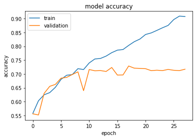

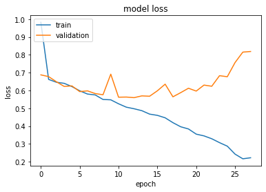

```python
#load data

dataDirectory="Dogs-vs-Cats/dataSet/"
output="Dogs-vs-Cats/trainResults/"
modelName='model_cnn_rgb'

#manage directory
if not os.path.exists(output):
    os.makedirs(output)

#parameter
batchSize=128
epochs=1000
validationSplit=0.30

features = dataDirectory+'data.npy'
X = np.load(features)

labels = dataDirectory+'labels.npy'
y = np.load(labels)

#%% Callbacks
callbacks=[]
callbacks.append(EarlyStopping(monitor='val_loss',patience=15,verbose=0, mode='auto'))
callbacks.append(ModelCheckpoint(output+modelName+'_check_.h5', save_best_only=True, monitor='val_loss', mode='min'))

seed = 7

#Split into train/test sets
X_train, X_val, y_train, y_val = train_test_split(X, y, test_size=validationSplit,random_state=seed,stratify=y)
steps_per_epoch=len(X_train)//batchSize

model=getCNN(np.shape(X[0]),2)

#compile model

opt=optimizers.SGD(lr=0.001,momentum=0.9)
model.compile(optimizer=opt , loss='categorical_crossentropy', metrics=['accuracy'])

#Train Model
t = time.time()
hist = model.fit(X_train, y_train, batch_size=batchSize, epochs=epochs,validation_data=(X_val, y_val), callbacks=callbacks,verbose=1)

elapsed = time.time() - t
print('Trainingduration: '+str(datetime.timedelta(seconds=elapsed)))

#save model
model.save(output+modelName+'.h5')

#generate and save plots
# plot history for accuracy
plt.figure()
plt.ioff()
plt.plot(hist.history['accuracy'])
plt.plot(hist.history['val_accuracy'])
plt.title('model accuracy')
plt.ylabel('accuracy')
plt.xlabel('epoch')
plt.legend(['train', 'validation'], loc='upper left')
plt.savefig(output+'_accuracy_'+modelName)

# plot history for loss
plt.figure()
plt.ioff()
plt.plot(hist.history['loss'])
plt.plot(hist.history['val_loss'])
plt.title('model loss')
plt.ylabel('loss')
plt.xlabel('epoch')
plt.legend(['train', 'validation'], loc='upper left')
plt.savefig(output+'_loss_'+modelName)

#save detail information
with open(output+modelName+".txt","w+") as f:

    f.write('Trainparameter:\n')
    f.write('ValidationSplit: {0}\n'.format(validationSplit))
    f.write('Batchsize: {0}\n'.format(batchSize))
    f.write('Epochs: {0}\n'.format(epochs))
    f.write('Steps per epoch: {0}\n'.format(steps_per_epoch))
    f.write('Inputdimension:\n'+str(np.shape(X_train[0])))
    f.write('\n')
    f.write('Results:\n')
    f.write('Trainaccuracy: {0}\n'.format(hist.history['accuracy'][-1]*100))
    f.write('Validationaccuracy: {0}\n'.format(hist.history['val_accuracy'][-1]*100))
    f.write('Best Validation: {0}\n'.format(np.max(hist.history['val_accuracy'])*100))
    f.write('\n')
    f.write('Modelarchitecture:\n')
    with redirect_stdout(f):
        model.summary()
```

```python
from tensorflow.keras.models import load_model
import imageio
import numpy as np
from tqdm import tqdm
from matplotlib import pyplot as plt
from matplotlib import image
import os
from sklearn.metrics import confusion_matrix
import cv2
import itertools
import pickle
```

```python
def plot_confusion_matrix(cm, classes,
                          normalize=False,
                          title='Confusion matrix',
                          cmap=plt.cm.Blues):
    """
    This function prints and plots the confusion matrix.
    Normalization can be applied by setting `normalize=True`.
    """
    plt.imshow(cm, interpolation='nearest', cmap=cmap)
    plt.title(title)
    plt.colorbar()
    tick_marks = np.arange(len(classes))
    plt.xticks(tick_marks, classes, rotation=45)
    plt.yticks(tick_marks, classes)

    if normalize:
        cm = cm.astype('float') / cm.sum(axis=1)[:, np.newaxis]
        print("Normalized confusion matrix")
    else:
        print('Confusion matrix, without normalization')

    print(cm)

    thresh = cm.max() / 2.
    for i, j in itertools.product(range(cm.shape[0]), range(cm.shape[1])):
        plt.text(j, i, cm[i, j],
                 horizontalalignment="center",
                 color="white" if cm[i, j] > thresh else "black")

    plt.tight_layout()
    plt.ylim(len(cm)-0.5, -0.5)
    plt.ylabel('True label')
    plt.xlabel('Predicted label')
```

```
load model
```

```
load image
```

```
Confusion matrix, without normalization
[[634 366]
 [228 772]]
```

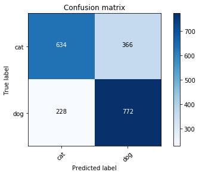

```
Testaccuracy: 0.7030000000000001
```

```python
#load model
print('load model')
modelPath="Dogs-vs-Cats/trainResults/"
modelName='model_cnn_rgb'
model = load_model(modelPath+modelName+'.h5')

#connect to image directory
print('load image')
imagePath="Dogs-vs-Cats/testDataSet/"
files=os.listdir(imagePath)

#load means
with open("Dogs-vs-Cats/means.pickle", "rb") as input_file:
    means = pickle.load(input_file)

#classification parameter
dim=model.input.shape.as_list()
classes={'cat':0,'dog':1}

actualClasses=[]
predictedClasses=[]
diff=[]

#iterate image files
for file in tqdm(files):
    #load image
    img = imageio.imread(imagePath+file,as_gray=False)
    label = classes[file.split('(')[0]]

    #scale image
    img = cv2.resize(img, dsize=(dim[1],dim[2]), interpolation=cv2.INTER_CUBIC)
    img = np.reshape(img,[1,dim[1],dim[2],3])
    prediction = model.predict(img)

    actualClasses.append(label)
    predictedClasses.append(np.argmax(prediction))

#confusion matrix
conf=confusion_matrix(actualClasses, predictedClasses)

plt.figure()
plot_confusion_matrix(conf, classes=list(classes.keys()), title='Confusion matrix')
plt.savefig(modelPath+'_confMat_'+modelName)
plt.show()

#calculate test accuracy
diff=[1 if x[0]!=x[1] else 0 for x in zip(actualClasses,predictedClasses)]
print('Testaccuracy: {0}'.format(1-sum(diff)/len(diff)))
```

**CNN with RGB images and batch-normalization + dropout:**

```
Train on 16100 samples, validate on 6900 samples
Trainingduration: 0:01:16.409572
```

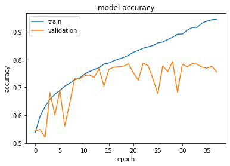

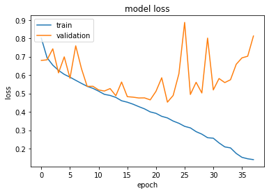

```python
#load data

dataDirectory="Dogs-vs-Cats/dataSet/"
output="Dogs-vs-Cats/trainResults/"
modelName='model_cnn_rgb_batchnorm'

#manage directory
if not os.path.exists(output):
    os.makedirs(output)

#parameter
batchSize=128
epochs=1000
validationSplit=0.30

features = dataDirectory+'data.npy'
X = np.load(features)

labels = dataDirectory+'labels.npy'
y = np.load(labels)

#%% Callbacks
callbacks=[]
callbacks.append(EarlyStopping(monitor='val_loss',patience=15,verbose=0, mode='auto'))
callbacks.append(ModelCheckpoint(output+modelName+'_check_.h5', save_best_only=True, monitor='val_loss', mode='min'))

seed = 7

#Split into train/test sets
X_train, X_val, y_train, y_val = train_test_split(X, y, test_size=validationSplit,random_state=seed,stratify=y)
steps_per_epoch=len(X_train)//batchSize

model=getCNN_batchnorm(np.shape(X[0]),2)

#compile model

opt=optimizers.SGD(lr=0.001,momentum=0.9)
model.compile(optimizer=opt , loss='categorical_crossentropy', metrics=['accuracy'])

#Train Model
t = time.time()
hist = model.fit(X_train, y_train, batch_size=batchSize, epochs=epochs,validation_data=(X_val, y_val), callbacks=callbacks,verbose=1)

elapsed = time.time() - t
print('Trainingduration: '+str(datetime.timedelta(seconds=elapsed)))

#save model
model.save(output+modelName+'.h5')

#generate and save plots
# plot history for accuracy
plt.figure()
plt.ioff()
plt.plot(hist.history['accuracy'])
plt.plot(hist.history['val_accuracy'])
plt.title('model accuracy')
plt.ylabel('accuracy')
plt.xlabel('epoch')
plt.legend(['train', 'validation'], loc='upper left')
plt.savefig(output+'_accuracy_'+modelName)

# plot history for loss
plt.figure()
plt.ioff()
plt.plot(hist.history['loss'])
plt.plot(hist.history['val_loss'])
plt.title('model loss')
plt.ylabel('loss')
plt.xlabel('epoch')
plt.legend(['train', 'validation'], loc='upper left')
plt.savefig(output+'_loss_'+modelName)

#save detail information
with open(output+modelName+".txt","w+") as f:

    f.write('Trainparameter:\n')
    f.write('ValidationSplit: {0}\n'.format(validationSplit))
    f.write('Batchsize: {0}\n'.format(batchSize))
    f.write('Epochs: {0}\n'.format(epochs))
    f.write('Steps per epoch: {0}\n'.format(steps_per_epoch))
    f.write('Inputdimension:\n'+str(np.shape(X_train[0])))
    f.write('\n')
    f.write('Results:\n')
    f.write('Trainaccuracy: {0}\n'.format(hist.history['accuracy'][-1]*100))
    f.write('Validationaccuracy: {0}\n'.format(hist.history['val_accuracy'][-1]*100))
    f.write('Best Validation: {0}\n'.format(np.max(hist.history['val_accuracy'])*100))
    f.write('\n')
    f.write('Modelarchitecture:\n')
    with redirect_stdout(f):
        model.summary()
```

```
load model
```

```
load image
```

```
Confusion matrix, without normalization
[[878 122]
 [383 617]]
```

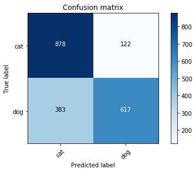

```
Testaccuracy: 0.7475
```

```python
#load model
print('load model')
modelPath="Dogs-vs-Cats/trainResults/"
modelName='model_cnn_rgb_batchnorm'
model = load_model(modelPath+modelName+'.h5')

#connect to image directory
print('load image')
imagePath="Dogs-vs-Cats/testDataSet/"
files=os.listdir(imagePath)

#load means
with open("Dogs-vs-Cats/means.pickle", "rb") as input_file:
    means = pickle.load(input_file)

#classification parameter
dim=model.input.shape.as_list()
classes={'cat':0,'dog':1}

actualClasses=[]
predictedClasses=[]
diff=[]

#iterate image files
for file in tqdm(files):
    #load image
    img = imageio.imread(imagePath+file,as_gray=False)
    label = classes[file.split('(')[0]]

    #scale image
    img = cv2.resize(img, dsize=(dim[1],dim[2]), interpolation=cv2.INTER_CUBIC)
    img = np.reshape(img,[1,dim[1],dim[2],3])
    prediction = model.predict(img)

    actualClasses.append(label)
    predictedClasses.append(np.argmax(prediction))

#confusion matrix
conf=confusion_matrix(actualClasses, predictedClasses)

plt.figure()
plot_confusion_matrix(conf, classes=list(classes.keys()), title='Confusion matrix')
plt.savefig(modelPath+'_confMat_'+modelName)
plt.show()

#calculate test accuracy
diff=[1 if x[0]!=x[1] else 0 for x in zip(actualClasses,predictedClasses)]
print('Testaccuracy: {0}'.format(1-sum(diff)/len(diff)))
```

**CNN with RGB images, batchnorm, dropout and L2-regularization:**

```
Train on 16100 samples, validate on 6900 samples
Trainingduration: 0:04:48.613761
```

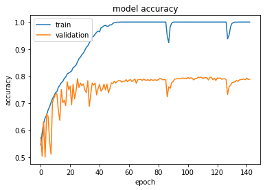

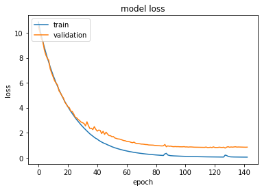

```python
#load data

dataDirectory="Dogs-vs-Cats/dataSet/"
output="Dogs-vs-Cats/trainResults/"
modelName='model_cnn_rgb_reg'

#manage directory
if not os.path.exists(output):
    os.makedirs(output)

#parameter
batchSize=128
epochs=1000
validationSplit=0.30

features = dataDirectory+'data.npy'
X = np.load(features)

labels = dataDirectory+'labels.npy'
y = np.load(labels)

#%% Callbacks
callbacks=[]
callbacks.append(EarlyStopping(monitor='val_loss',patience=15,verbose=0, mode='auto'))
callbacks.append(ModelCheckpoint(output+modelName+'_check_.h5', save_best_only=True, monitor='val_loss', mode='min'))

seed = 7

#Split into train/test sets
X_train, X_val, y_train, y_val = train_test_split(X, y, test_size=validationSplit,random_state=seed,stratify=y)
steps_per_epoch=len(X_train)//batchSize

model=getCNN_reg(np.shape(X[0]),2)

#compile model

opt=optimizers.SGD(lr=0.001,momentum=0.9)
model.compile(optimizer=opt , loss='categorical_crossentropy', metrics=['accuracy'])

#Train Model
t = time.time()
hist = model.fit(X_train, y_train, batch_size=batchSize, epochs=epochs,validation_data=(X_val, y_val), callbacks=callbacks,verbose=1)

elapsed = time.time() - t
print('Trainingduration: '+str(datetime.timedelta(seconds=elapsed)))

#save model
model.save(output+modelName+'.h5')

#generate and save plots
# plot history for accuracy
plt.figure()
plt.ioff()
plt.plot(hist.history['accuracy'])
plt.plot(hist.history['val_accuracy'])
plt.title('model accuracy')
plt.ylabel('accuracy')
plt.xlabel('epoch')
plt.legend(['train', 'validation'], loc='upper left')
plt.savefig(output+'_accuracy_'+modelName)

# plot history for loss
plt.figure()
plt.ioff()
plt.plot(hist.history['loss'])
plt.plot(hist.history['val_loss'])
plt.title('model loss')
plt.ylabel('loss')
plt.xlabel('epoch')
plt.legend(['train', 'validation'], loc='upper left')
plt.savefig(output+'_loss_'+modelName)

#save detail information
with open(output+modelName+".txt","w+") as f:

    f.write('Trainparameter:\n')
    f.write('ValidationSplit: {0}\n'.format(validationSplit))
    f.write('Batchsize: {0}\n'.format(batchSize))
    f.write('Epochs: {0}\n'.format(epochs))
    f.write('Steps per epoch: {0}\n'.format(steps_per_epoch))
    f.write('Inputdimension:\n'+str(np.shape(X_train[0])))
    f.write('\n')
    f.write('Results:\n')
    f.write('Trainaccuracy: {0}\n'.format(hist.history['accuracy'][-1]*100))
    f.write('Validationaccuracy: {0}\n'.format(hist.history['val_accuracy'][-1]*100))
    f.write('Best Validation: {0}\n'.format(np.max(hist.history['val_accuracy'])*100))
    f.write('\n')
    f.write('Modelarchitecture:\n')
    with redirect_stdout(f):
        model.summary()
```

```
load model
```

```
load image
```

```
Confusion matrix, without normalization
[[789 211]
 [230 770]]
```

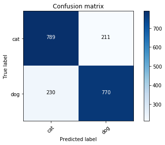

```
Testaccuracy: 0.7795
```

```python
#load model
print('load model')
modelPath="Dogs-vs-Cats/trainResults/"
modelName='model_cnn_rgb_reg'
model = load_model(modelPath+modelName+'.h5')

#connect to image directory
print('load image')
imagePath="Dogs-vs-Cats/testDataSet/"
files=os.listdir(imagePath)

#load means
with open("Dogs-vs-Cats/means.pickle", "rb") as input_file:
    means = pickle.load(input_file)

#classification parameter
dim=model.input.shape.as_list()
classes={'cat':0,'dog':1}

actualClasses=[]
predictedClasses=[]
diff=[]

#iterate image files
for file in tqdm(files):
    #load image
    img = imageio.imread(imagePath+file,as_gray=False)
    label = classes[file.split('(')[0]]

    #scale image
    img = cv2.resize(img, dsize=(dim[1],dim[2]), interpolation=cv2.INTER_CUBIC)
    img = np.reshape(img,[1,dim[1],dim[2],3])
    prediction = model.predict(img)

    actualClasses.append(label)
    predictedClasses.append(np.argmax(prediction))

#confusion matrix
conf=confusion_matrix(actualClasses, predictedClasses)

plt.figure()
plot_confusion_matrix(conf, classes=list(classes.keys()), title='Confusion matrix')
plt.savefig(modelPath+'_confMat_'+modelName)
plt.show()

#calculate test accuracy
diff=[1 if x[0]!=x[1] else 0 for x in zip(actualClasses,predictedClasses)]
print('Testaccuracy: {0}'.format(1-sum(diff)/len(diff)))
```

**ResNet with RGB images:**

```
Downloading data from https://github.com/keras-team/keras-applications/releases/download/resnet/resnet50_weights_tf_dim_ordering_tf_kernels_notop.h5
Train on 16100 samples, validate on 6900 samples
Trainingduration: 0:09:25.602365
```

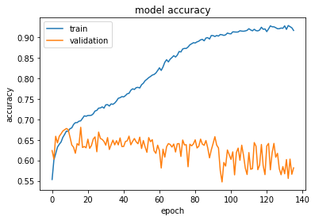

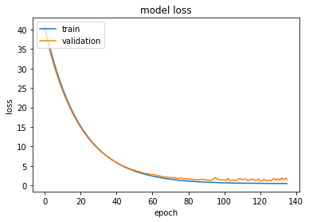

```python
#load data

dataDirectory="Dogs-vs-Cats/dataSet/"
output="Dogs-vs-Cats/trainResults/"
modelName='model_cnn_rgb_resnet'

#manage directory
if not os.path.exists(output):
    os.makedirs(output)

#parameter
batchSize=128
epochs=1000
validationSplit=0.30

features = dataDirectory+'data.npy'
X = np.load(features)

labels = dataDirectory+'labels.npy'
y = np.load(labels)

#%% Callbacks
callbacks=[]
callbacks.append(EarlyStopping(monitor='val_loss',patience=15,verbose=0, mode='auto'))
callbacks.append(ModelCheckpoint(output+modelName+'_check_.h5', save_best_only=True, monitor='val_loss', mode='min'))

seed = 7

#Split into train/test sets
X_train, X_val, y_train, y_val = train_test_split(X, y, test_size=validationSplit,random_state=seed,stratify=y)
steps_per_epoch=len(X_train)//batchSize

model=getResnet(np.shape(X[0]),2)

#compile model

opt=optimizers.SGD(lr=0.001,momentum=0.9)
model.compile(optimizer=opt , loss='categorical_crossentropy', metrics=['accuracy'])

#Train Model
t = time.time()
hist = model.fit(X_train, y_train, batch_size=batchSize, epochs=epochs,validation_data=(X_val, y_val), callbacks=callbacks,verbose=1)

elapsed = time.time() - t
print('Trainingduration: '+str(datetime.timedelta(seconds=elapsed)))

#save model
model.save(output+modelName+'.h5')

#generate and save plots
# plot history for accuracy
plt.figure()
plt.ioff()
plt.plot(hist.history['accuracy'])
plt.plot(hist.history['val_accuracy'])
plt.title('model accuracy')
plt.ylabel('accuracy')
plt.xlabel('epoch')
plt.legend(['train', 'validation'], loc='upper left')
plt.savefig(output+'_accuracy_'+modelName)

# plot history for loss
plt.figure()
plt.ioff()
plt.plot(hist.history['loss'])
plt.plot(hist.history['val_loss'])
plt.title('model loss')
plt.ylabel('loss')
plt.xlabel('epoch')
plt.legend(['train', 'validation'], loc='upper left')
plt.savefig(output+'_loss_'+modelName)

#save detail information
with open(output+modelName+".txt","w+") as f:

    f.write('Trainparameter:\n')
    f.write('ValidationSplit: {0}\n'.format(validationSplit))
    f.write('Batchsize: {0}\n'.format(batchSize))
    f.write('Epochs: {0}\n'.format(epochs))
    f.write('Steps per epoch: {0}\n'.format(steps_per_epoch))
    f.write('Inputdimension:\n'+str(np.shape(X_train[0])))
    f.write('\n')
    f.write('Results:\n')
    f.write('Trainaccuracy: {0}\n'.format(hist.history['accuracy'][-1]*100))
    f.write('Validationaccuracy: {0}\n'.format(hist.history['val_accuracy'][-1]*100))
    f.write('Best Validation: {0}\n'.format(np.max(hist.history['val_accuracy'])*100))
    f.write('\n')
    f.write('Modelarchitecture:\n')
    with redirect_stdout(f):
        model.summary()
```

```
load model
```

```
load image
```

```
Confusion matrix, without normalization
[[243 757]
 [ 71 929]]
```

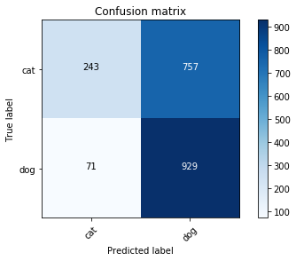

```
Testaccuracy: 0.5860000000000001
```

```python
#load model
print('load model')
modelPath="Dogs-vs-Cats/trainResults/"
modelName='model_cnn_rgb_resnet'
model = load_model(modelPath+modelName+'.h5')

#connect to image directory
print('load image')
imagePath="Dogs-vs-Cats/testDataSet/"
files=os.listdir(imagePath)

#load means
with open("Dogs-vs-Cats/means.pickle", "rb") as input_file:
    means = pickle.load(input_file)

#classification parameter
dim=model.input.shape.as_list()
classes={'cat':0,'dog':1}

actualClasses=[]
predictedClasses=[]
diff=[]

#iterate image files
for file in tqdm(files):
    #load image
    img = imageio.imread(imagePath+file,as_gray=False)
    label = classes[file.split('(')[0]]

    #scale image
    img = cv2.resize(img, dsize=(dim[1],dim[2]), interpolation=cv2.INTER_CUBIC)
    img = np.reshape(img,[1,dim[1],dim[2],3])
    prediction = model.predict(img)

    actualClasses.append(label)
    predictedClasses.append(np.argmax(prediction))

#confusion matrix
conf=confusion_matrix(actualClasses, predictedClasses)

plt.figure()
plot_confusion_matrix(conf, classes=list(classes.keys()), title='Confusion matrix')
plt.savefig(modelPath+'_confMat_'+modelName)
plt.show()

#calculate test accuracy
diff=[1 if x[0]!=x[1] else 0 for x in zip(actualClasses,predictedClasses)]
print('Testaccuracy: {0}'.format(1-sum(diff)/len(diff)))
```

**VGG16 with RGB images:**

```
Downloading data from https://github.com/fchollet/deep-learning-models/releases/download/v0.1/vgg16_weights_tf_dim_ordering_tf_kernels_notop.h5
Train on 16100 samples, validate on 6900 samples
Trainingduration: 0:02:24.291040
```

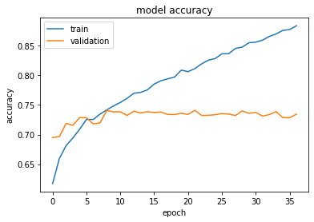

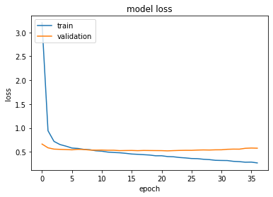

```python
#load data

dataDirectory="Dogs-vs-Cats/dataSet/"
output="Dogs-vs-Cats/trainResults/"
modelName='model_cnn_rgb_vgg'

#manage directory
if not os.path.exists(output):
    os.makedirs(output)

#parameter
batchSize=128
epochs=1000
validationSplit=0.30

features = dataDirectory+'data.npy'
X = np.load(features)

labels = dataDirectory+'labels.npy'
y = np.load(labels)

#%% Callbacks
callbacks=[]
callbacks.append(EarlyStopping(monitor='val_loss',patience=15,verbose=0, mode='auto'))
callbacks.append(ModelCheckpoint(output+modelName+'_check_.h5', save_best_only=True, monitor='val_loss', mode='min'))

seed = 7

#Split into train/test sets
X_train, X_val, y_train, y_val = train_test_split(X, y, test_size=validationSplit,random_state=seed,stratify=y)
steps_per_epoch=len(X_train)//batchSize

model=vgg16(np.shape(X[0]),2)

#compile model

opt=optimizers.SGD(lr=0.001,momentum=0.9)
model.compile(optimizer=opt , loss='categorical_crossentropy', metrics=['accuracy'])

#Train Model
t = time.time()
hist = model.fit(X_train, y_train, batch_size=batchSize, epochs=epochs,validation_data=(X_val, y_val), callbacks=callbacks,verbose=1)

elapsed = time.time() - t
print('Trainingduration: '+str(datetime.timedelta(seconds=elapsed)))

#save model
model.save(output+modelName+'.h5')

#generate and save plots
# plot history for accuracy
plt.figure()
plt.ioff()
plt.plot(hist.history['accuracy'])
plt.plot(hist.history['val_accuracy'])
plt.title('model accuracy')
plt.ylabel('accuracy')
plt.xlabel('epoch')
plt.legend(['train', 'validation'], loc='upper left')
plt.savefig(output+'_accuracy_'+modelName)

# plot history for loss
plt.figure()
plt.ioff()
plt.plot(hist.history['loss'])
plt.plot(hist.history['val_loss'])
plt.title('model loss')
plt.ylabel('loss')
plt.xlabel('epoch')
plt.legend(['train', 'validation'], loc='upper left')
plt.savefig(output+'_loss_'+modelName)

#save detail information
with open(output+modelName+".txt","w+") as f:

    f.write('Trainparameter:\n')
    f.write('ValidationSplit: {0}\n'.format(validationSplit))
    f.write('Batchsize: {0}\n'.format(batchSize))
    f.write('Epochs: {0}\n'.format(epochs))
    f.write('Steps per epoch: {0}\n'.format(steps_per_epoch))
    f.write('Inputdimension:\n'+str(np.shape(X_train[0])))
    f.write('\n')
    f.write('Results:\n')
    f.write('Trainaccuracy: {0}\n'.format(hist.history['accuracy'][-1]*100))
    f.write('Validationaccuracy: {0}\n'.format(hist.history['val_accuracy'][-1]*100))
    f.write('Best Validation: {0}\n'.format(np.max(hist.history['val_accuracy'])*100))
    f.write('\n')
    f.write('Modelarchitecture:\n')
    with redirect_stdout(f):
        model.summary()
```

```
load model
```

```
load image
```

```
Confusion matrix, without normalization
[[786 214]
 [302 698]]
```

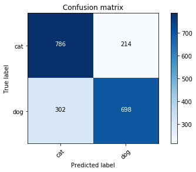

```
Testaccuracy: 0.742
```

```python
#load model
print('load model')
modelPath="Dogs-vs-Cats/trainResults/"
modelName='model_cnn_rgb_vgg'
model = load_model(modelPath+modelName+'.h5')

#connect to image directory
print('load image')
imagePath="Dogs-vs-Cats/testDataSet/"
files=os.listdir(imagePath)

#load means
with open("Dogs-vs-Cats/means.pickle", "rb") as input_file:
    means = pickle.load(input_file)

#classification parameter
dim=model.input.shape.as_list()
classes={'cat':0,'dog':1}

actualClasses=[]
predictedClasses=[]
diff=[]

#iterate image files
for file in tqdm(files):
    #load image
    img = imageio.imread(imagePath+file,as_gray=False)
    label = classes[file.split('(')[0]]

    #scale image
    img = cv2.resize(img, dsize=(dim[1],dim[2]), interpolation=cv2.INTER_CUBIC)
    img = np.reshape(img,[1,dim[1],dim[2],3])
    prediction = model.predict(img)

    actualClasses.append(label)
    predictedClasses.append(np.argmax(prediction))

#confusion matrix
conf=confusion_matrix(actualClasses, predictedClasses)

plt.figure()
plot_confusion_matrix(conf, classes=list(classes.keys()), title='Confusion matrix')
plt.savefig(modelPath+'_confMat_'+modelName)
plt.show()

#calculate test accuracy
diff=[1 if x[0]!=x[1] else 0 for x in zip(actualClasses,predictedClasses)]
print('Testaccuracy: {0}'.format(1-sum(diff)/len(diff)))
```

**CNN with RGB images and Data Augmentation**

[output not shown]

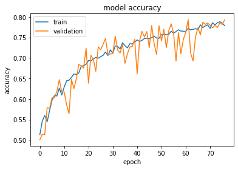

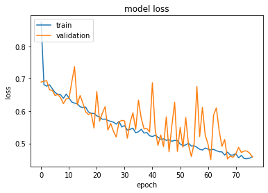

```python
#load data

dataDirectory="Dogs-vs-Cats/dataSet/"
output="Dogs-vs-Cats/trainResults/"
modelName='model_cnn_rgb_aug'

#manage directory
if not os.path.exists(output):
    os.makedirs(output)

#parameter
batchSize=128
epochs=1000
validationSplit=0.30

features = dataDirectory+'data.npy'
X = np.load(features)

labels = dataDirectory+'labels.npy'
y = np.load(labels)

#%% Callbacks
callbacks=[]
callbacks.append(EarlyStopping(monitor='val_loss',patience=15,verbose=0, mode='auto'))
callbacks.append(ModelCheckpoint(output+modelName+'_check_.h5', save_best_only=True, monitor='val_loss', mode='min'))

seed = 7

#Split into train/test sets
X_train, X_val, y_train, y_val = train_test_split(X, y, test_size=validationSplit,random_state=seed,stratify=y)
steps_per_epoch=len(X_train)//batchSize

model=getCNN(np.shape(X[0]),2)

#compile model

opt=optimizers.SGD(lr=0.001,momentum=0.9)
model.compile(optimizer=opt , loss='categorical_crossentropy', metrics=['accuracy'])

#data augmentation
aug = ImageDataGenerator(
        rotation_range=10,  # rotate in degrees
        zoom_range = 0.1, # zoom
        width_shift_range=0.2,  # shift images horizontally
        height_shift_range=0.2,  # shift images vertically
        horizontal_flip=True,  # flip images
        vertical_flip=False)  # flip images

#Train Model
t = time.time()
hist = model.fit_generator(aug.flow(X_train, y_train, batch_size=batchSize), validation_data=(X_val, y_val), steps_per_epoch=steps_per_epoch, epochs=epochs, callbacks=callbacks, verbose=1)

elapsed = time.time() - t
print('Trainingduration: '+str(datetime.timedelta(seconds=elapsed)))

#save model
model.save(output+modelName+'.h5')

#generate and save plots
# plot history for accuracy
plt.figure()
plt.ioff()
plt.plot(hist.history['accuracy'])
plt.plot(hist.history['val_accuracy'])
plt.title('model accuracy')
plt.ylabel('accuracy')
plt.xlabel('epoch')
plt.legend(['train', 'validation'], loc='upper left')
plt.savefig(output+'_accuracy_'+modelName)

# plot history for loss
plt.figure()
plt.ioff()
plt.plot(hist.history['loss'])
plt.plot(hist.history['val_loss'])
plt.title('model loss')
plt.ylabel('loss')
plt.xlabel('epoch')
plt.legend(['train', 'validation'], loc='upper left')
plt.savefig(output+'_loss_'+modelName)

#save detail information
with open(output+modelName+".txt","w+") as f:

    f.write('Trainparameter:\n')
    f.write('ValidationSplit: {0}\n'.format(validationSplit))
    f.write('Batchsize: {0}\n'.format(batchSize))
    f.write('Epochs: {0}\n'.format(epochs))
    f.write('Steps per epoch: {0}\n'.format(steps_per_epoch))
    f.write('Inputdimension:\n'+str(np.shape(X_train[0])))
    f.write('\n')
    f.write('Results:\n')
    f.write('Trainaccuracy: {0}\n'.format(hist.history['accuracy'][-1]*100))
    f.write('Validationaccuracy: {0}\n'.format(hist.history['val_accuracy'][-1]*100))
    f.write('Best Validation: {0}\n'.format(np.max(hist.history['val_accuracy'])*100))
    f.write('\n')
    f.write('Modelarchitecture:\n')
    with redirect_stdout(f):
        model.summary()
```

```
load model
```

```
load image
```

```
Confusion matrix, without normalization
[[736 264]
 [154 846]]
```

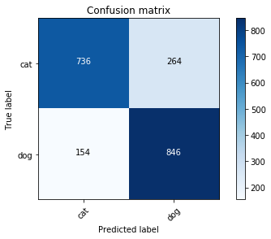

```
Testaccuracy: 0.791
```

```python
#load model
print('load model')
modelPath="Dogs-vs-Cats/trainResults/"
modelName='model_cnn_rgb_aug'
model = load_model(modelPath+modelName+'.h5')

#connect to image directory
print('load image')
imagePath="Dogs-vs-Cats/testDataSet/"
files=os.listdir(imagePath)

#load means
with open("Dogs-vs-Cats/means.pickle", "rb") as input_file:
    means = pickle.load(input_file)

#classification parameter
dim=model.input.shape.as_list()
classes={'cat':0,'dog':1}

actualClasses=[]
predictedClasses=[]
diff=[]

#iterate image files
for file in tqdm(files):
    #load image
    img = imageio.imread(imagePath+file,as_gray=False)
    label = classes[file.split('(')[0]]

    #scale image
    img = cv2.resize(img, dsize=(dim[1],dim[2]), interpolation=cv2.INTER_CUBIC)
    img = np.reshape(img,[1,dim[1],dim[2],3])
    prediction = model.predict(img)

    actualClasses.append(label)
    predictedClasses.append(np.argmax(prediction))

#confusion matrix
conf=confusion_matrix(actualClasses, predictedClasses)

plt.figure()
plot_confusion_matrix(conf, classes=list(classes.keys()), title='Confusion matrix')
plt.savefig(modelPath+'_confMat_'+modelName)
plt.show()

#calculate test accuracy
diff=[1 if x[0]!=x[1] else 0 for x in zip(actualClasses,predictedClasses)]
print('Testaccuracy: {0}'.format(1-sum(diff)/len(diff)))
```

**CNN with RGB Images, Batch-Normalization, Dropout and Data Augmentation:**

```
WARNING:tensorflow:sample_weight modes were coerced from
  ...
    to
  ['...']
Train for 125 steps, validate on 6900 samples
Trainingduration: 0:08:26.888479
```

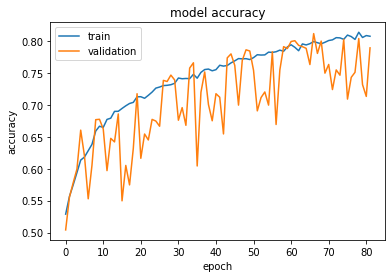

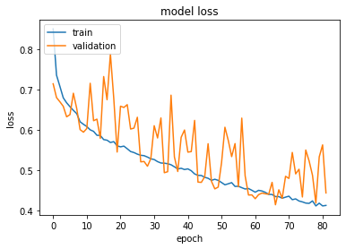

```python
#load data

dataDirectory="Dogs-vs-Cats/dataSet/"
output="Dogs-vs-Cats/trainResults/"
modelName='model_cnn_rgb_batchnorm_aug'

#manage directory
if not os.path.exists(output):
    os.makedirs(output)

#parameter
batchSize=128
epochs=1000
validationSplit=0.30

features = dataDirectory+'data.npy'
X = np.load(features)

labels = dataDirectory+'labels.npy'
y = np.load(labels)

#%% Callbacks
callbacks=[]
callbacks.append(EarlyStopping(monitor='val_loss',patience=15,verbose=0, mode='auto'))
callbacks.append(ModelCheckpoint(output+modelName+'_check_.h5', save_best_only=True, monitor='val_loss', mode='min'))

seed = 7

#Split into train/test sets
X_train, X_val, y_train, y_val = train_test_split(X, y, test_size=validationSplit,random_state=seed,stratify=y)
steps_per_epoch=len(X_train)//batchSize

model=getCNN_batchnorm(np.shape(X[0]),2)

#compile model

opt=optimizers.SGD(lr=0.001,momentum=0.9)
model.compile(optimizer=opt , loss='categorical_crossentropy', metrics=['accuracy'])

#data augmentation
aug = ImageDataGenerator(
        rotation_range=10,  # rotate in degrees
        zoom_range = 0.1, # zoom
        width_shift_range=0.2,  # shift images horizontally
        height_shift_range=0.2,  # shift images vertically
        horizontal_flip=True,  # flip images
        vertical_flip=False)  # flip images

#Train Model
t = time.time()
hist = model.fit_generator(aug.flow(X_train, y_train, batch_size=batchSize), validation_data=(X_val, y_val), steps_per_epoch=steps_per_epoch, epochs=epochs, callbacks=callbacks, verbose=1)

elapsed = time.time() - t
print('Trainingduration: '+str(datetime.timedelta(seconds=elapsed)))

#save model
model.save(output+modelName+'.h5')

#generate and save plots
# plot history for accuracy
plt.figure()
plt.ioff()
plt.plot(hist.history['accuracy'])
plt.plot(hist.history['val_accuracy'])
plt.title('model accuracy')
plt.ylabel('accuracy')
plt.xlabel('epoch')
plt.legend(['train', 'validation'], loc='upper left')
plt.savefig(output+'_accuracy_'+modelName)

# plot history for loss
plt.figure()
plt.ioff()
plt.plot(hist.history['loss'])
plt.plot(hist.history['val_loss'])
plt.title('model loss')
plt.ylabel('loss')
plt.xlabel('epoch')
plt.legend(['train', 'validation'], loc='upper left')
plt.savefig(output+'_loss_'+modelName)

#save detail information
with open(output+modelName+".txt","w+") as f:

    f.write('Trainparameter:\n')
    f.write('ValidationSplit: {0}\n'.format(validationSplit))
    f.write('Batchsize: {0}\n'.format(batchSize))
    f.write('Epochs: {0}\n'.format(epochs))
    f.write('Steps per epoch: {0}\n'.format(steps_per_epoch))
    f.write('Inputdimension:\n'+str(np.shape(X_train[0])))
    f.write('\n')
    f.write('Results:\n')
    f.write('Trainaccuracy: {0}\n'.format(hist.history['accuracy'][-1]*100))
    f.write('Validationaccuracy: {0}\n'.format(hist.history['val_accuracy'][-1]*100))
    f.write('Best Validation: {0}\n'.format(np.max(hist.history['val_accuracy'])*100))
    f.write('\n')
    f.write('Modelarchitecture:\n')
    with redirect_stdout(f):
        model.summary()
```

```
load model
```

```
load image
```

```
Confusion matrix, without normalization
[[668 332]
 [ 77 923]]
```

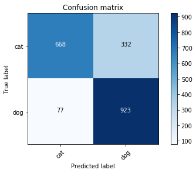

```
Testaccuracy: 0.7955
```

```python
#load model
print('load model')
modelPath="Dogs-vs-Cats/trainResults/"
modelName='model_cnn_rgb_batchnorm_aug'
model = load_model(modelPath+modelName+'.h5')

#connect to image directory
print('load image')
imagePath="Dogs-vs-Cats/testDataSet/"
files=os.listdir(imagePath)

#load means
with open("Dogs-vs-Cats/means.pickle", "rb") as input_file:
    means = pickle.load(input_file)

#classification parameter
dim=model.input.shape.as_list()
classes={'cat':0,'dog':1}

actualClasses=[]
predictedClasses=[]
diff=[]

#iterate image files
for file in tqdm(files):
    #load image
    img = imageio.imread(imagePath+file,as_gray=False)
    label = classes[file.split('(')[0]]

    #scale image
    img = cv2.resize(img, dsize=(dim[1],dim[2]), interpolation=cv2.INTER_CUBIC)
    img = np.reshape(img,[1,dim[1],dim[2],3])
    prediction = model.predict(img)

    actualClasses.append(label)
    predictedClasses.append(np.argmax(prediction))

#confusion matrix
conf=confusion_matrix(actualClasses, predictedClasses)

plt.figure()
plot_confusion_matrix(conf, classes=list(classes.keys()), title='Confusion matrix')
plt.savefig(modelPath+'_confMat_'+modelName)
plt.show()

#calculate test accuracy
diff=[1 if x[0]!=x[1] else 0 for x in zip(actualClasses,predictedClasses)]
print('Testaccuracy: {0}'.format(1-sum(diff)/len(diff)))
```

**CNN with RGB Images, Batch-Normalization, Dropout, L2-Regularization and Data Augmentation:**

```
WARNING:tensorflow:sample_weight modes were coerced from
  ...
    to
  ['...']
Train for 125 steps, validate on 6900 samples
Trainingduration: 0:16:29.125109
```

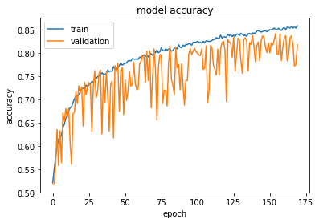

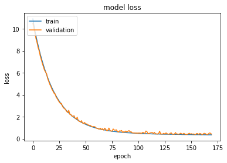

```python
#load data

dataDirectory="Dogs-vs-Cats/dataSet/"
output="Dogs-vs-Cats/trainResults/"
modelName='model_cnn_rgb_reg_aug'

#manage directory
if not os.path.exists(output):
    os.makedirs(output)

#parameter
batchSize=128
epochs=1000
validationSplit=0.30

features = dataDirectory+'data.npy'
X = np.load(features)

labels = dataDirectory+'labels.npy'
y = np.load(labels)

#%% Callbacks
callbacks=[]
callbacks.append(EarlyStopping(monitor='val_loss',patience=15,verbose=0, mode='auto'))
callbacks.append(ModelCheckpoint(output+modelName+'_check_.h5', save_best_only=True, monitor='val_loss', mode='min'))

seed = 7

#Split into train/test sets
X_train, X_val, y_train, y_val = train_test_split(X, y, test_size=validationSplit,random_state=seed,stratify=y)
steps_per_epoch=len(X_train)//batchSize

model=getCNN_reg(np.shape(X[0]),2)

#compile model

opt=optimizers.SGD(lr=0.001,momentum=0.9)
model.compile(optimizer=opt , loss='categorical_crossentropy', metrics=['accuracy'])

#data augmentation
aug = ImageDataGenerator(
        rotation_range=10,  # rotate in degrees
        zoom_range = 0.1, # zoom
        width_shift_range=0.2,  # shift images horizontally
        height_shift_range=0.2,  # shift images vertically
        horizontal_flip=True,  # flip images
        vertical_flip=False)  # flip images

#Train Model
t = time.time()
hist = model.fit_generator(aug.flow(X_train, y_train, batch_size=batchSize), validation_data=(X_val, y_val), steps_per_epoch=steps_per_epoch, epochs=epochs, callbacks=callbacks, verbose=1)

elapsed = time.time() - t
print('Trainingduration: '+str(datetime.timedelta(seconds=elapsed)))

#save model
model.save(output+modelName+'.h5')

#generate and save plots
# plot history for accuracy
plt.figure()
plt.ioff()
plt.plot(hist.history['accuracy'])
plt.plot(hist.history['val_accuracy'])
plt.title('model accuracy')
plt.ylabel('accuracy')
plt.xlabel('epoch')
plt.legend(['train', 'validation'], loc='upper left')
plt.savefig(output+'_accuracy_'+modelName)

# plot history for loss
plt.figure()
plt.ioff()
plt.plot(hist.history['loss'])
plt.plot(hist.history['val_loss'])
plt.title('model loss')
plt.ylabel('loss')
plt.xlabel('epoch')
plt.legend(['train', 'validation'], loc='upper left')
plt.savefig(output+'_loss_'+modelName)

#save detail information
with open(output+modelName+".txt","w+") as f:

    f.write('Trainparameter:\n')
    f.write('ValidationSplit: {0}\n'.format(validationSplit))
    f.write('Batchsize: {0}\n'.format(batchSize))
    f.write('Epochs: {0}\n'.format(epochs))
    f.write('Steps per epoch: {0}\n'.format(steps_per_epoch))
    f.write('Inputdimension:\n'+str(np.shape(X_train[0])))
    f.write('\n')
    f.write('Results:\n')
    f.write('Trainaccuracy: {0}\n'.format(hist.history['accuracy'][-1]*100))
    f.write('Validationaccuracy: {0}\n'.format(hist.history['val_accuracy'][-1]*100))
    f.write('Best Validation: {0}\n'.format(np.max(hist.history['val_accuracy'])*100))
    f.write('\n')
    f.write('Modelarchitecture:\n')
    with redirect_stdout(f):
        model.summary()
```